# San Francisco Employee Salaries Data Analysis

### Corelation Heatmap

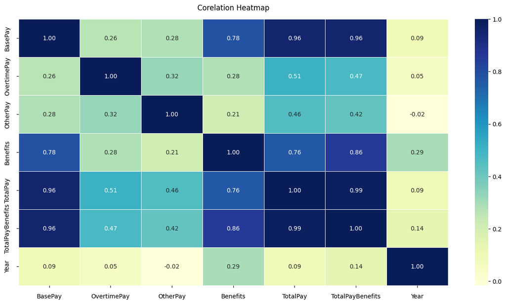

```python
# set chart style properties
plt.figure(figsize=(16,8))

# Create Heatmap
ax = sns.heatmap(df.corr(numeric_only=True),
            annot=True,
            fmt='.2f',
            linewidths=.5,
            cmap="YlGnBu")

# set Heatmap properties
plt.title('Corelation Heatmap', y=1.02)
ax.tick_params(axis='both',pad=10)
plt.show()
```

- **Strongest Positive Correlation:** The darkest squares on the heatmap show a very strong positive correlation (a value close to 1.0) between TotalPayBenefits and TotalPay. This means as an employee's total pay increases, their total pay with benefits also increases in a very predictable way.
- **Other High Correlations:** BasePay also has a very strong positive correlation with TotalPay and TotalPayBenefits. This indicates that the base salary is a major contributing factor to an employee's overall compensation.
- **Moderate Correlation:** There is a moderate positive correlation between Benefits and both TotalPay and BasePay. This suggests that employees with higher salaries tend to receive more benefits, but the relationship is not as strong as the one between TotalPay and TotalPayBenefits.
- **Weakest Correlation:** OvertimePay and OtherPay have the weakest correlation with the other variables. Their values are not strongly tied to BasePay, Benefits, or TotalPay, suggesting they are more variable and less predictable.

The heatmap provides a clear and concise visual summary of the relationships between the different compensation variables. The most significant finding is the extremely strong positive correlation between TotalPayBenefits, TotalPay, and BasePay, which highlights that an employee's base salary is the primary driver of their overall compensation package. In contrast, OvertimePay and OtherPay are more independent variables, having a weak relationship with the core compensation structure. This indicates that total pay is largely a function of an employee's base salary, with benefits contributing significantly and other pay types being less influential.

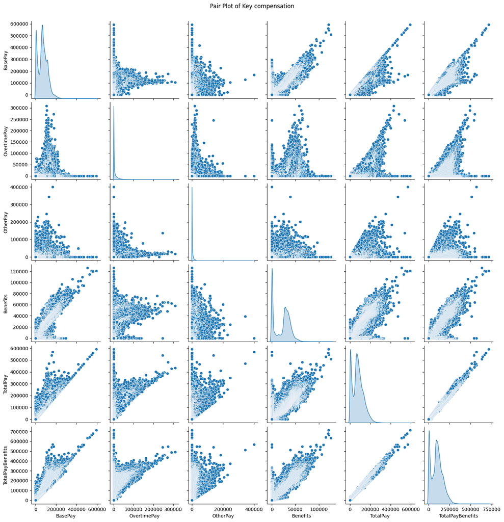

```python
sns.pairplot(data=df[['BasePay', 'OvertimePay', 'OtherPay', 'Benefits', 'TotalPay', 'TotalPayBenefits']],
             diag_kind="kde")
plt.suptitle('Pair Plot of Key compensation', y=1.02)
plt.show()
```

- **BasePay, TotalPay, Benefits, and TotalPayBenefits** all show a right-skewed distribution, meaning the majority of values are concentrated at the lower end, with a long tail of higher values.
- This indicates that most employees have lower compensation, while a smaller number of employees receive significantly higher pay and benefits.
- There is a **very strong positive linear relationship** between **TotalPayBenefits and both TotalPay and BasePay.** The scatter points form a tight, upward-sloping line, indicating that as one variable increases, the other increases proportionally.
- A **strong positive linear relationship** also exists between **TotalPay and BasePay,** suggesting that base salary is the primary component of total pay.
- Benefits show a positive, but **slightly weaker, linear relationship with TotalPayBenefits, TotalPay, and BasePay.** The scatter plots are a bit more spread out, indicating that while higher compensation generally comes with higher benefits, the relationship is not as perfectly linear.